## Third Markdown Assignmennt

### Intro

Weather conditions greatly change the environment of the driver to the point where even a great driver can incur fatal injuries if they are not wary of the weather. Precipitation is one of the common forms of weather and is also one of the largest factors in the safety of motorcycle riders. This study was conducted to determine the correlation between weather conditions and the number of fatalities among motorcycle riders.

$H_0: \mu_{rainy}=mu_{dry}$ $H_1: \mu_{rainy}\neq\mu_{dry}$

at $\alpha=0.05$

### Results

```
##    ï..Country  Dry Rain
## 1          AT   92    3
## 2          BE  116    4
## 3          CZ  107    4
## 4          DK   19    1
## 5          EE    4    0
## 6          ES  471    8
## 7          FI   24    0
## 8          FR  727   39
## 9          GB  530   26
## 10         GR  423   12
## 11         HU   87    2
## 12         IT 1009   32
## 13         LV   10    0
## 14         MT    2    0
## 15         NI   12    2
## 16         NL   53    4
## 17         PT  129    6
## 18         SE   52    1
```

#### Dry season fatalities

$\mu = 214.8333$  
$\sigma = 293.2388$

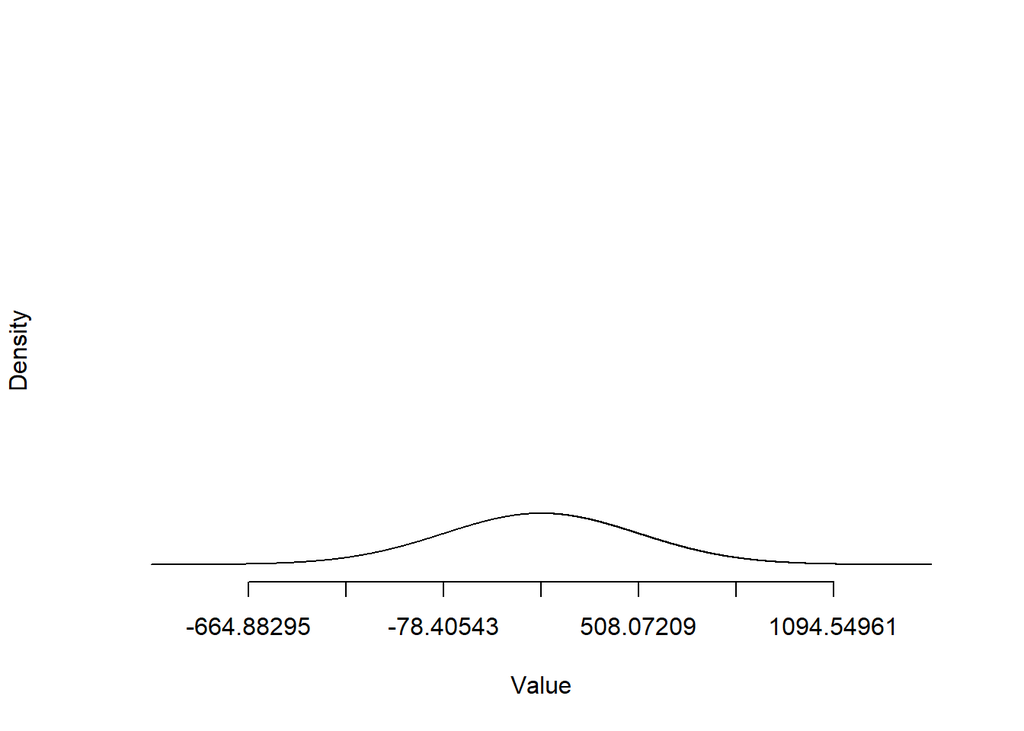

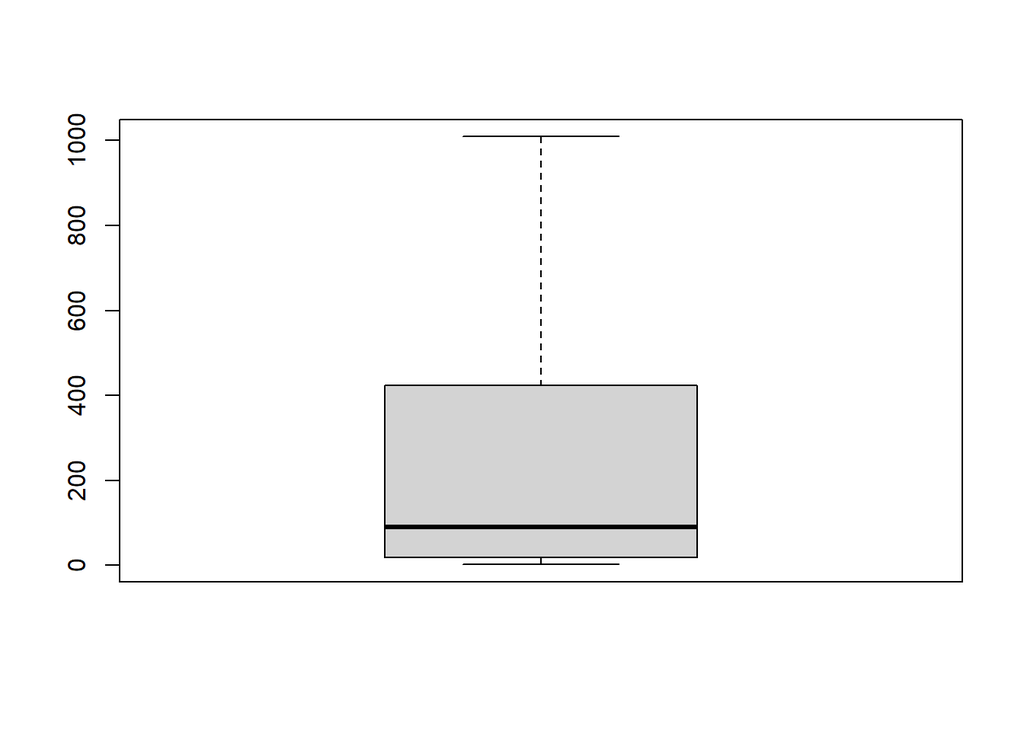

#### Wet season fatalities

$\mu = 8$  
$\sigma = 11.83216$

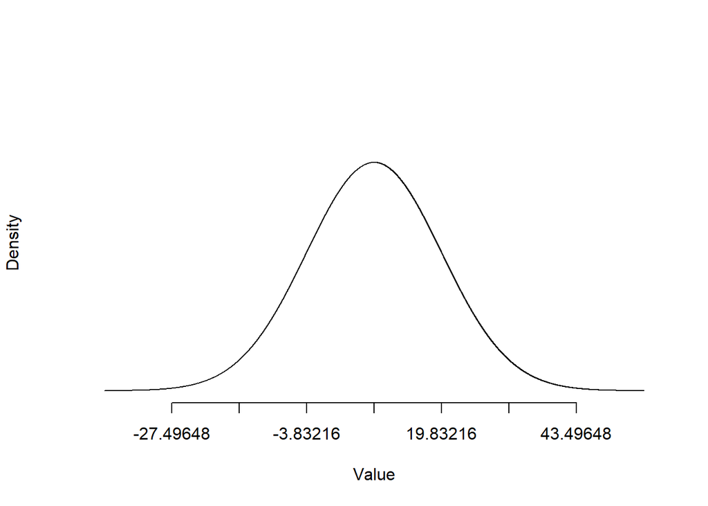

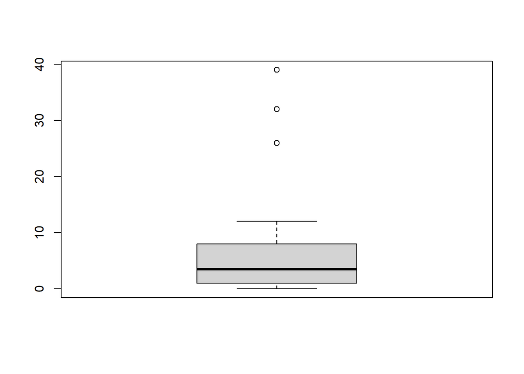

#### Hypothesis testing

$H_0: μ_1 = μ_2$  
$H1: μ_1 ≠ μ_2$  
$α = 0.05$

$$z_0=\frac{\mu_1-\mu_2}{\sqrt{\frac{\sigma_1^2}{n_1}+\frac{\sigma_2^2}{n_2}}}$$

$Z_0 = 2.990076$

$P(2.990076) = 0.001394542$  
$0.001394542 < 0.025$

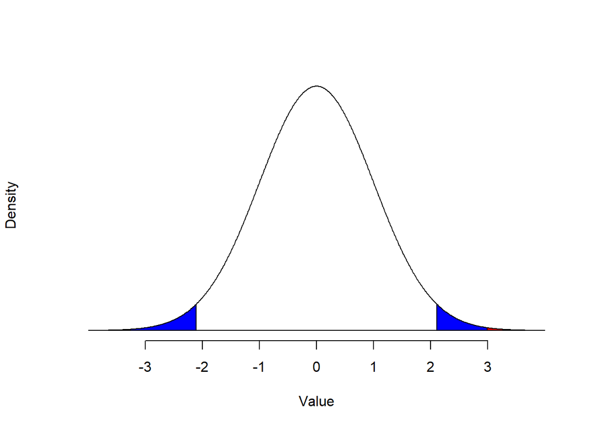

### Discussions

There is a significant difference between the fatalities that happened in the wet and dry season. The results state that there is actually a clear correlation between motorcycle accidents and the weather condition. There are a lot of factors to consider why accidents are more likely to happen during dry season; but it can be simply assumed that during wet season motorcyclists are more careful in the road and/or riders generally choose not to ride when the road is wet. Future researches concerning two-wheeled road accidents can use the data the results’ of the study provides as a reference.

### Conclusion

Although the difference is not what you would expect because there is a lot more fatalities in the dry season rather than the rain. The reason behind this could be that no is riding there motorcycles when it is raining and that they are only riding it when the sun is out. Motorcycle riders could also be more cautious when driving in more precarious weather conditions than dry conditions, explaining the large difference in fatalities between rainy and dry weather conditions.